# MIDI-MT - Оборудование DMX512/ArtNet

MIDI-MT Документация на Русском языке

## Репитеры, повторители и конвертеры протоколов

Для реализации объединения сетевых технологий **ArtNet**, **MQTT** и **DMX512** в единую систему управления световыми приборами можно использовать не только оборудование известных производителей. Гораздо дешевле, использовать для этих целей `Arduino` подобные платы с поддержкой технологии `WiFi`, спроектированные на чтпсетах `ESP`, например `ESP8266`, `ESP32` и т.д.

При этом, получается получить прибор с максимальными возможностями по минимальной цене. Бюджет такого устройства обойдется в стоимость примерно одного трекового светильника, другими словами, его стоимость выйдет примерно в `10-15%` от цены аналогично фирменного оборудования.

Одна из таких конструкций, служащая для расширения охвата сети умных устройств, работает под управлением программы **MIDI-MT**, для которой была специально разработана. Простота исполнения и наличие в широкой продаже электронных компонентов делают её универсальной.

Схематехника «Репитера» и «Конечной точки» очень проста, в тестовом экземпляре используется готовая плата микроконтроллера, разработки LOLIN (Wemos) на чипсете `ESP8266` и готовую плату преобразователя `TTL` уровней в интерфейс `RS485`. Ограничений нет, можно использовать любые доступные аналоги.

## Монтаж и подключение производится согласно схеме:

Устройство «Репитер»

[figure not shown]

Устройство «Конечная точка»

[figure not shown]

### подключение преобразователя TTL уровней в интерфейс RS485

- pin `DE` (data enable) к контакту на микроконтроллере (Wemos - pin D2)
- pin `RE` (receive enable) к контакту на микроконтроллере (Wemos - pin D2)
- pin `DI` (data in) соединить с D4/TX1 на микроконтроллере (Wemos - pin D4)
- pin `VCC` соединить с питанием 5V
- pin `A` выход DMX сигнала, к шине управления освещением (разъем XLR pin 3, разъем Ethernet pin 1)
- pin `B` выход DMX сигнала, к шине управления освещением (разъем XLR pin 2, разъем Ethernet pin 2)
- pin `GND` земля, выход DMX, к шине управления освещением (разъем XLR pin 1, разъем Ethernet pin 7,8)

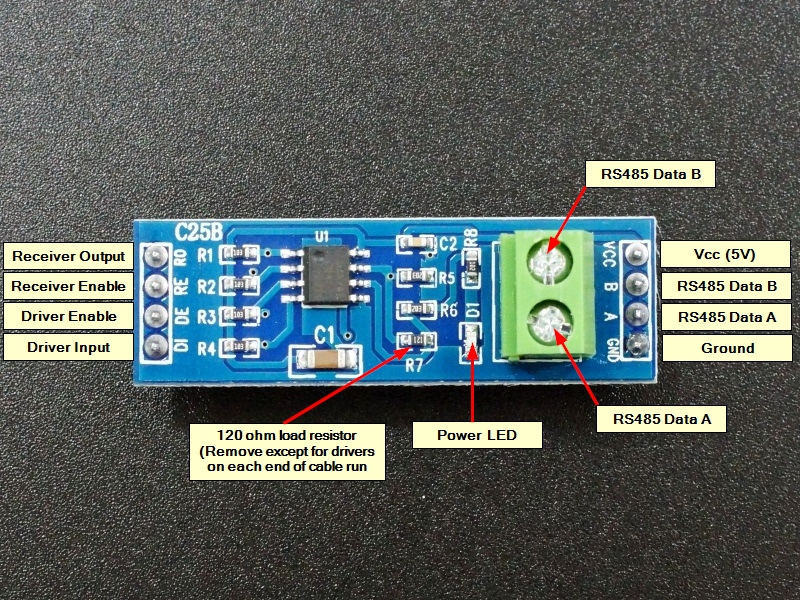

MIDI-MT RS485 to DMX512 Endpoint

### Настройки

Устройства «Репитер» и «Конечная точка» используют `HTTP` сервер, для получения конфигурации сети **DMX512** в `json` формате. Имя `json` файла конфигурации составляется по следующей схеме:

- имена `art-dmx-XXX-XXX` относятся к устройству «Репитер».
- имена `art-ep-XXX-XXX` относятся к устройству «Конечная точка».
- общая часть наименования: `art-dmx` или `art-ep`
- имя хоста: `art-dmx-1-2` или `art-ep-1-2`
- полное доменное имя: `art-dmx-1-2.local` или `art-ep-1-2.local`, где цифры 1 и 2 являются частью IP адреса выданного устройству: 192.168.1.2
- имя файла конфигурации: `art-dmx-1-2.json` или `art-ep-1-2.json`

#### пример `json` файла настроек устройств «Репитер» или «Конечная точка»

**sub** - полное название MQTT топика.  
**dmx** - номер канала в сети DMX512.

```yaml
  {"mqtt":[
     {"sub":"sensor/ctrl9/av9/slider","dmx":9},
     {"sub":"sensor/ctrl9/b21/onoff","dmx":10},
     {"sub":"sensor/ctrl9/b22/onoff","dmx":11},
     {"sub":"sensor/ctrl9/b23/onoff","dmx":12}
]}
```

Один из вариантов размещения конфигураций, использовать встроенный веб сервер в MQTT демоне `mosquitto`. Для этого необходимо разрешить использование веб-сокетов и прописать путь до каталога с `json` конфигурацией.

#### пример настройки mosquitto.conf

```
per_listener_settings true

listener 1883
protocol mqtt
socket_domain ipv4

user mosquitto

allow_anonymous false
retain_available true
use_username_as_clientid true
allow_zero_length_clientid true
auto_id_prefix auto-
queue_qos0_messages false
sys_interval 90
autosave_interval 1800
autosave_on_changes true

persistence true
persistent_client_expiration 1m
persistence_location /var/lib/mosquitto/

password_file /etc/mosquitto/pass.cfg
acl_file /etc/mosquitto/mosquitto.acl
pid_file /run/mosquitto/mosquitto.pid

log_dest syslog
log_type warning

listener 9001
protocol websockets
# путь до каталога с `json` конфигурацией
http_dir /srv/git/linuxconfig/mqttweb
```

#### пример настройки mosquitto.acl

```
topic read $SYS/#
pattern readwrite sensor/%u/#
pattern write $SYS/broker/connection/%c/state

# !!! добавить !!!
# имя (логин) репитера (art-dmx-XXX-XXX) или конечной точки (art-ep-XXX-XXX)
# для доступа в режиме чтения!
user art-dmx-0-11
topic read #

user art-ep-0-12
topic read #

# ваши права администратора на доступ к топикам.
user admin
topic readwrite #
```

#### настройки конфигурации сборки

Основные настройки находятся в файле `config.h.default`. Вам необходимо отредактировать его и переименовать в `config.h`.

Параметры:

- `USING_HTTP_AS_GW` - определяет местонахождение MQTT и HTTP сервера как IP адрес WiFi гейта (роутер).
- `USING_HTTP_AS_HOST` - указывается IP адрес MQTT и HTTP сервера, цифры вводятся через запятую, без пробелов.
- `USING_HTTP_PORT` - определяет порт HTTP сервера.
- `USING_MQTT_SUBSCRIBE` - MQTT топик для подписки и прослушивания.
- `USING_MQTT_PASSWORD` - пароль для MQTT сервера, логином является имя узла, которое генерируется автоматически.
- `USING_MQTT_STATE` - MQTT топик для индикации состояния устройства.
- `USING_MQTT_PORT` - порт MQTT сервера.
- `USING_MQTT_ID` - использовать расширенный MQTT идентификатор, используется для работы с одной учётной записи нескольких устройств, применять не рекомендуется.
- `DEBUG` - сборка кода в режиме отладки, с выводом на `USB Serial`. Не следует использовать на рабочем экземпляре, так как создаётся дополнительная нагрузка на память микроконтроллера.
- `SEND_DMX_CODE_T1` - варианты формирования заголовков DMX пакета, изменять не рекомендуется.
- `PIN_ERROR` - контакт для подключения индикатора состояния (Wemos - pin D1 светодиод).

Для устройства «Репитер»:

- `USING_ARTNET_FILTER` - пропускать из сети ArtNet только DMX каналы указанные в конфигурации.
- `PIN_RS485_UP` - контакт для активации интерфейса RS485 (Wemos - pin D2).
- `PIN_RS485_TX` - контакт TX интерфейса RS485 (Wemos - pin D4)

Для устройства «Конечная точка»:

- `USING_MODE_ONOF` - определяет алгоритм управления нагрузкой: реле или ШИМ модули. При использовании реле, значение должно быть `1`. При использовании в качестве диммера, значение должно быть `0`.
- `PINS_OUT` - список контактов к которым подключена нагрузка: реле или ШИМ модули (Wemos - pins: D2, D5, D6, D7).

### Назначение и особенности

В задачи устройства «Репитер» входит собирать управляющую информацию о состоянии включения осветительных приборов из сетей **ArtNet** и **MQTT**, далее информация суммируется и передается по протоколу **DMX** в проводную сеть, через которую идет реальное управление освещением. Использование подразумевает наличие проводной сети **DMX512** и точки подключения к ней.

Устройство «Конечная точка» обрабатывает данные полученные из сетей **ArtNet** и **MQTT**. Эти данные используються для физического управления блоками реле или диммерами подключенными к устройству.

Управление может осуществляться по протоколам **ArtNet** и **MQTT**. Стандартный режим работы, это одновременное использование протоколов **ArtNet** и **MQTT** для формирования исходящего DMX потока, или управления конечными устройствами.

Команды управления **MQTT** имеют преимущество перед командами **ArtNet**. Если ичточник был включен с помощью **MQTT** управления, его отключение может быть осуществлено только им. Это относится к любым регулировкам, как к включению и выключению, так и к регулировке яркости или изменения цвета. Напротив, если осветительный прибор был включен командами из **ArtNet** источника, дальнейшее управление могут взять на себя управляющие сигналы по протоколу **MQTT**.

#### Схемы и прошивки

Схемы и прошивки можно скачать [тут](https://github.com/ClaudiaCoord/MIDI-MT-MQTT-ArtNet-Repeater-to-DMX512).